# An Analysis of Bob Ross’s happy trees

Names: Natalie, Zoe, and Aiym

Describing Data and Research Question:

Our data is an analysis of Bob Ross’s paintings that show when certain elements of nature such as trees or rocks appear in his work. This data set comes from the fivethirtyeight package in R studio and it was collected by counting the number of certain objects in 403 of his paintings. We hope to learn more about how specific elements in his paintings influence the likelihood that a tree will appear in that same piece of artwork.

Question: We will work to examine how the frequencies of specific variables (clouds, rocks, and flowers) in his paintings affect the likelihood of trees appearing in his works.

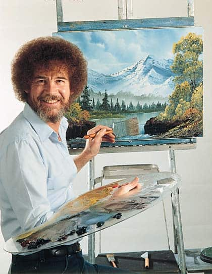

Bob Ross

### Graphs

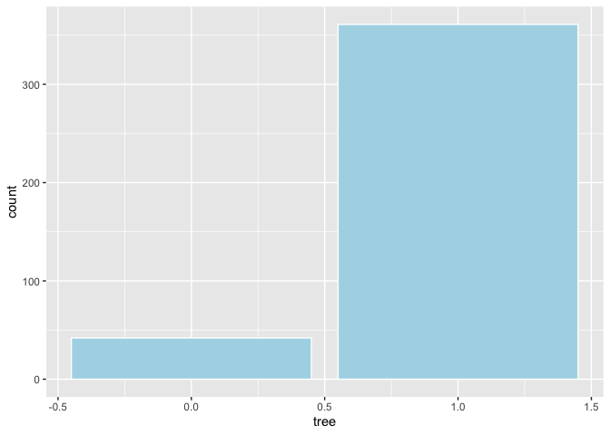

The vast majority of Bob Ross’s paintings have trees in them.

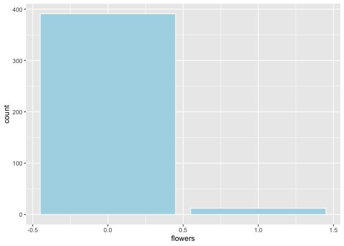

The vast majority of Bob Ross’s paintings do NOT have flowers in them.

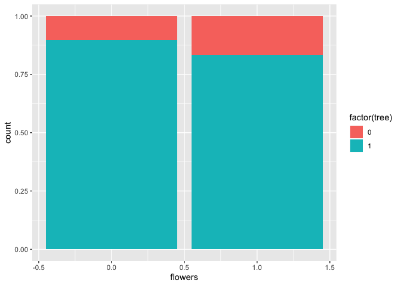

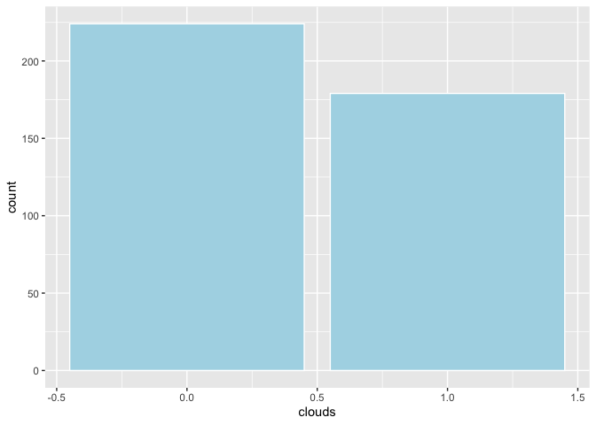

Approximately half of his paintings have clouds in them and half of them do not.

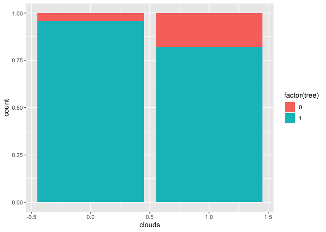

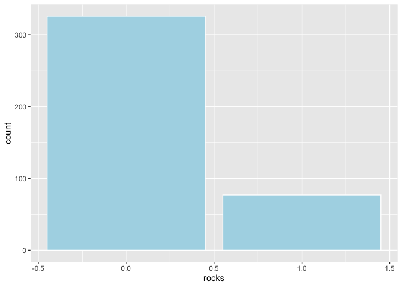

Most of his paintings do not have rocks in them, but there are about 75 that do.

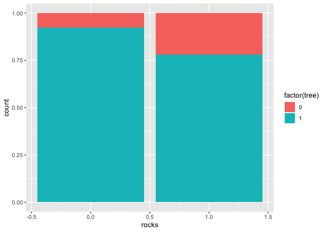

About 75% of the paintings that have rocks have trees.

### Models

```
## # A tibble: 2 x 3
##   term        estimate exp_est
##   <chr>          <dbl>   <dbl>
## 1 (Intercept)    2.17    8.77
## 2 flowers       -0.562   0.570
```

```
## # A tibble: 2 x 4
##   term        upperCI lowerCI  p.value
##   <chr>         <dbl>   <dbl>    <dbl>
## 1 (Intercept)    2.51    1.84 9.97e-39
## 2 flowers        1.02   -2.15 4.78e- 1
```

```
## # A tibble: 2 x 3
##   term        estimate exp_est
##   <chr>          <dbl>   <dbl>
## 1 (Intercept)     3.06  21.4
## 2 clouds         -1.54   0.215
```

```
## # A tibble: 2 x 4
##   term        upperCI lowerCI  p.value
##   <chr>         <dbl>   <dbl>    <dbl>
## 1 (Intercept)   3.71     2.42 2.80e-21
## 2 clouds       -0.783   -2.29 4.64e- 5
```

[figure not shown]

A Painting with a Trees and Clouds

```
## # A tibble: 2 x 3
##   term        estimate exp_est
##   <chr>          <dbl>   <dbl>
## 1 (Intercept)     2.49  12.0
## 2 rocks          -1.23   0.293
```

```
## # A tibble: 2 x 4
##   term        upperCI lowerCI  p.value
##   <chr>         <dbl>   <dbl>    <dbl>
## 1 (Intercept)   2.90     2.07 6.14e-33
## 2 rocks        -0.538   -1.92 3.71e- 4
```

```
## # A tibble: 3 x 3
##   term        estimate exp_est
##   <chr>          <dbl>   <dbl>
## 1 (Intercept)     3.31  27.5
## 2 rocks          -1.10   0.334
## 3 clouds         -1.46   0.233
```

```
## # A tibble: 3 x 4
##   term        upperCI lowerCI  p.value
##   <chr>         <dbl>   <dbl>    <dbl>
## 1 (Intercept)   4.00     2.63 6.63e-22
## 2 rocks        -0.385   -1.81 2.05e- 3
## 3 clouds       -0.691   -2.22 1.39e- 4
```

### Hypothesis Testing

H0: There is no relationship between tree and flowers (Beta 1 = 0). Ha: There is a relationship between tree and flowers (Beta 1 does not equal 0)

```
## # A tibble: 2 x 2
##   term         p.value
##   <chr>          <dbl>
## 1 (Intercept) 9.97e-39
## 2 flowers     4.78e- 1
```

The p value is greater than .05 there we cannot reject the null hypothesis and determine that there is no relationship between flowers and tree.

H0: There is no relationship between tree and clouds (Beta 1 = 0). Ha: There is a relationship between tree and clouds (Beta 1 does not equal 0)

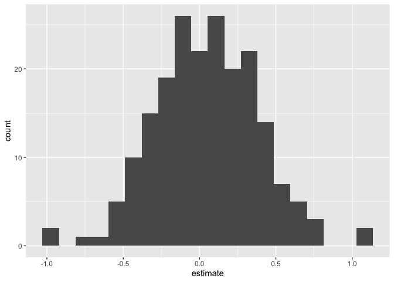

```
## # A tibble: 1 x 1
##   p_value
##     <dbl>
## 1       0
```

The p-value of 0 means that if the true coefficient of the clouds was 0, the chances we’d see an estimated coefficient of -1.455180 or something more extreme is 0. So it’s unlikely to observe something like we observed in our data when the null hypothesis is true. Thus, we have evidence to reject the null hypothesis, i.e. there is evidence that there is a relationship between the presence of clouds in the painting and the presence of a tree on the same painting.

H0: There is no relationship between tree and rocks (Beta 1 = 0). Ha: There is a relationship between tree and rocks (Beta 1 does not equal 0)

```
## # A tibble: 2 x 2
##   term         p.value
##   <chr>          <dbl>
## 1 (Intercept) 6.14e-33
## 2 rocks       3.71e- 4
```

The p-value is less the 0.05 therefore we can reject the null hypothesis, meaning there is a relationship between trees, and rocks.

H0: There is no relationship between tree and rocks, accounted for clouds (Beta 1 = 0). Ha: There is a relationship between tree and rocks, accounted for clouds (Beta 1 does not equal 0)

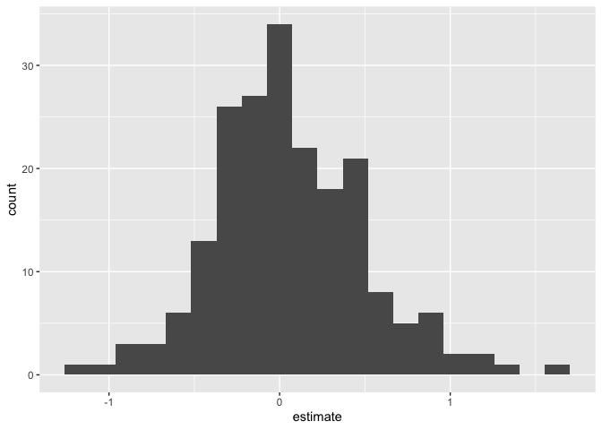

```
## # A tibble: 1 x 1
##   p_value
##     <dbl>
## 1       0
```

The p-value is less the 0.05 therefore we can reject the null hypothesis, meaning there is a relationship between trees and rocks, while accounting for clouds.

[figure not shown]

Painting with Trees, Clouds, and Rocks

### Summary

Based off of our research, it was found that there are certain objects that influence the likelihood of a tree appearing in Bob Ross’s paintings. It is more likely that there will be relationship between tree and the object if the object is in many paintings. It was found that clouds and rocks influence the presence of a tree in a painting compared to having flowers in the painting, which shows there is no relationship.

Some challenges we faced with our dataset was that some variables only appeared in a small number of his paintings which interfered with the results. Also if there were only a few paintings with both a tree and the specific object we were analyzing, our exponentiated estimate and other statistic were very insigfiicant because some samples were taken without those observations being drawn.